# eda

#### Medical_History_1-41

A set of normalized variables relating to the medical history of the applicant.

```
##
## --- Medical_History_1 ---
## integer
##    Min. 1st Qu.  Median    Mean 3rd Qu.    Max.    NA's
##   0.000   2.000   4.000   7.929   9.000 240.000   11861
## Table
##     0     1     2     3     4     5     6     7     8     9    10    11
##  6336 10111  7583  6361  4912  4321  3983  2816  2224  1975  1749  1577
##    12    13    14    15    16    17    18    19    20    21    22    23
##  2317  1133   948   753   688   617   602   445   361   342   341   333
##    24    25    26    27    28    29    30    31    32    33    34    35
##   445   250   239   242   188   196   188   155   118   126   108   111
##    36    37    38    39    40    41    42    43    44    45    46    47
##   131    85    86    92    73    54    63    66    56    44    41    42
##    48    49    50    51    52    53    54    55    56    57    58    59
##    56    38    57    37    48    39    47    50    43    41    23    33
##    60    61    62    63    64    65    66    67    68    69    70    71
##    46    18    23    24    30    22    16    15    16    18    15    13
##    72    73    74    75    76    77    78    79    80    81    82    83
##    15    10     7    11    19     9    14    12     7    10    13     9
##    84    85    86    87    88    89    90    91    92    93    94    95
##     9    11     9     9    11     5    13     8    10     7     8     9
##    96    97    98    99   100   101   102   103   104   105   106   107
##     9     7     5     6     7     5     2     3     3     2     2     3
##   108   109   110   111   112   113   114   115   116   117   118   119
##     6     5     8     4     5     3     4     5     6     6     3     3
##   120   121   122   123   124   125   126   127   128   130   131   132
##    13     4     7     7     2     3     3     2     3     1     2     1
##   134   136   137   138   141   143   145   146   147   148   150   153
##     6     2     1     2     1     1     3     4     3     3     2     1
##   154   155   156   158   159   160   161   162   163   169   171   172
##     2     2     1     2     2     2     1     1     1     3     2     1
##   173   174   175   176   178   179   180   182   185   187   189   191
##     5     1     1     2     1     2     4     4     1     1     1     1
##   193   201   223   225   228   229   233   235   239   240
##     1     1     1     1     1     1     1     1     1     3
##
## --- Medical_History_2 ---
## integer
##    Min. 1st Qu.  Median    Mean 3rd Qu.    Max.
```

[output cut: 489 more lines]

```
## --- Medical_History_40 ---
## integer
##    Min. 1st Qu.  Median    Mean 3rd Qu.    Max.
##   1.000   3.000   3.000   2.968   3.000   3.000
## Table
##     1     2     3
##  1263     4 77879
##
## --- Medical_History_41 ---
## integer
##    Min. 1st Qu.  Median    Mean 3rd Qu.    Max.
##   1.000   1.000   1.000   1.644   3.000   3.000
## Table
##     1     2     3
## 53663     1 25482
```

According to the data documentation, Medical_History_1, Medical_History_15, Medical_History_24, Medical_History_32 are discrete variables.

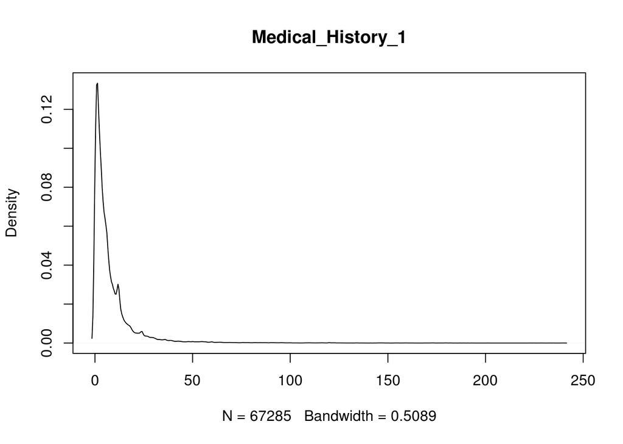

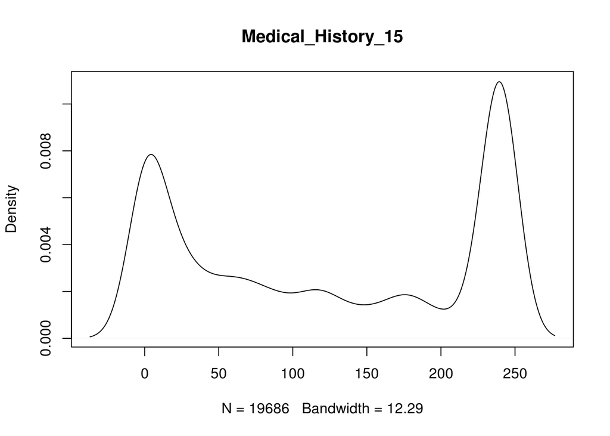

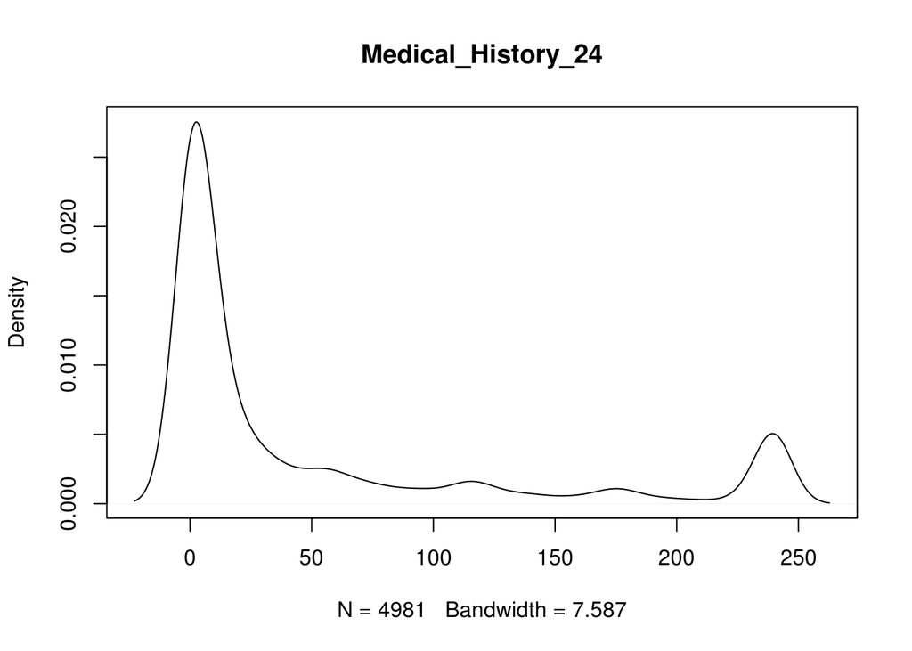

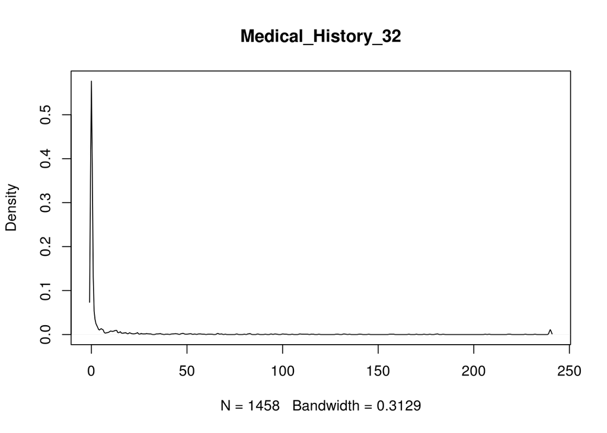

#### Medical_Keyword_1-48

A set of dummy variables relating to the presence of/absence of a medical keyword being associated with the application.

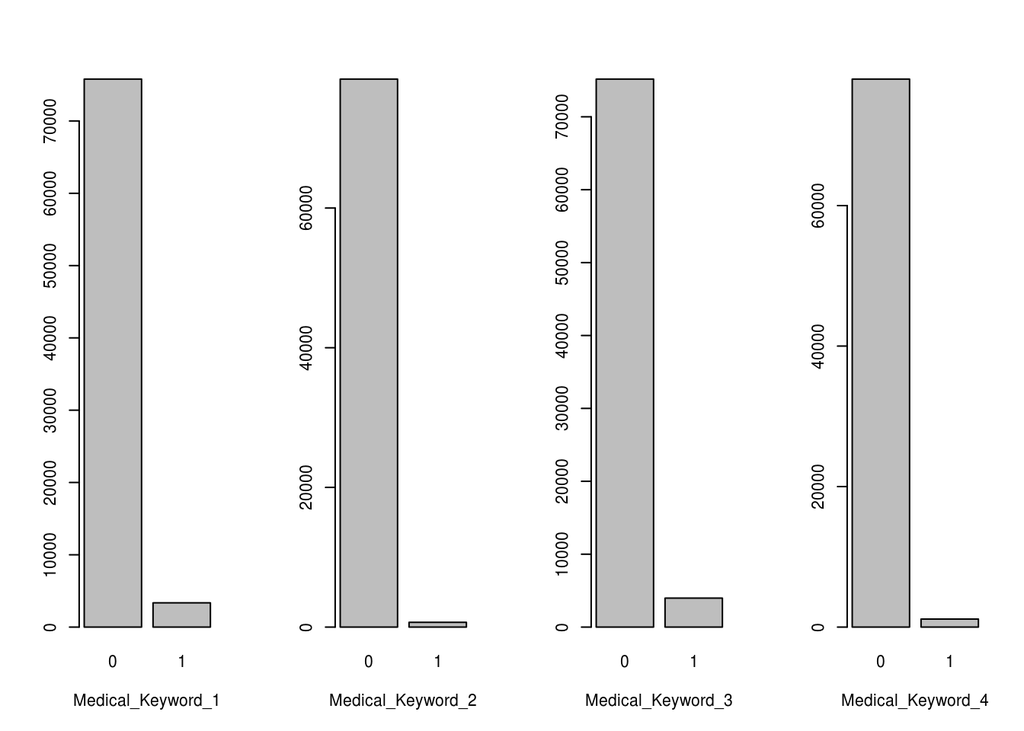

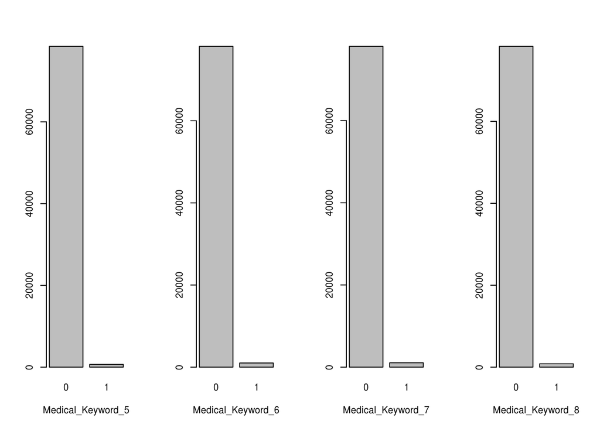

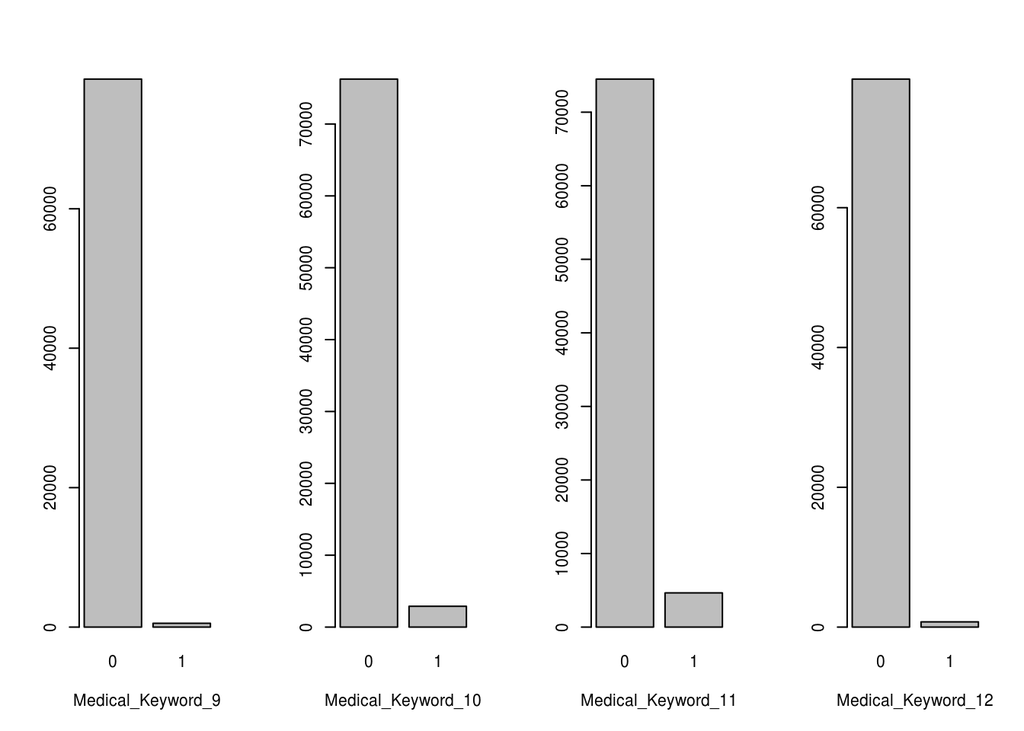

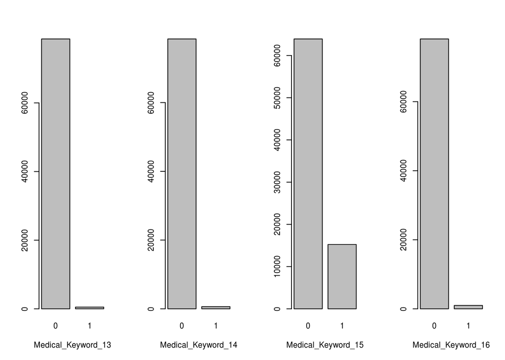

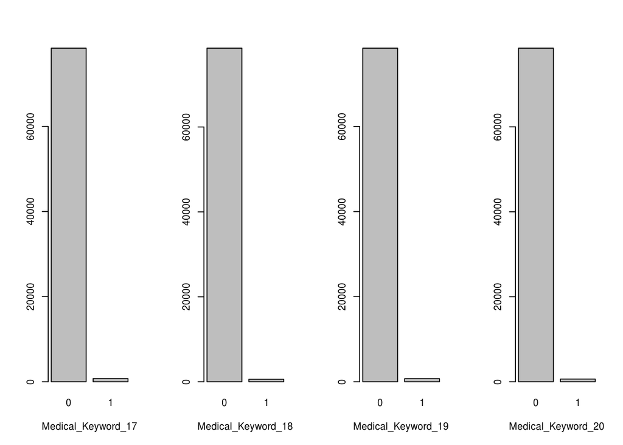

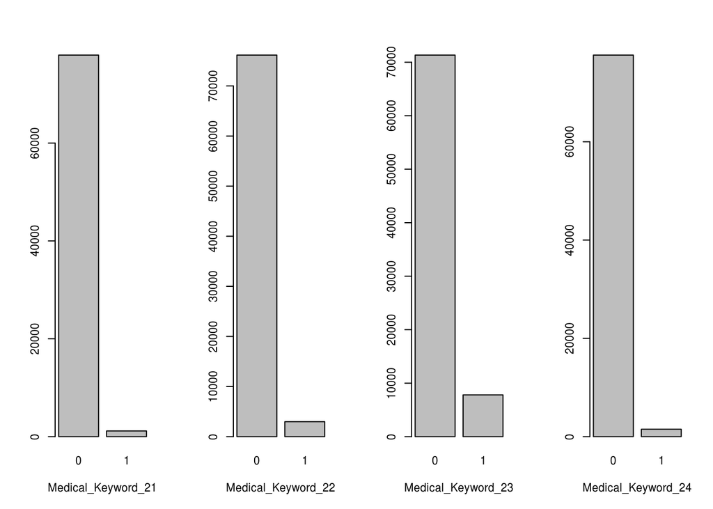

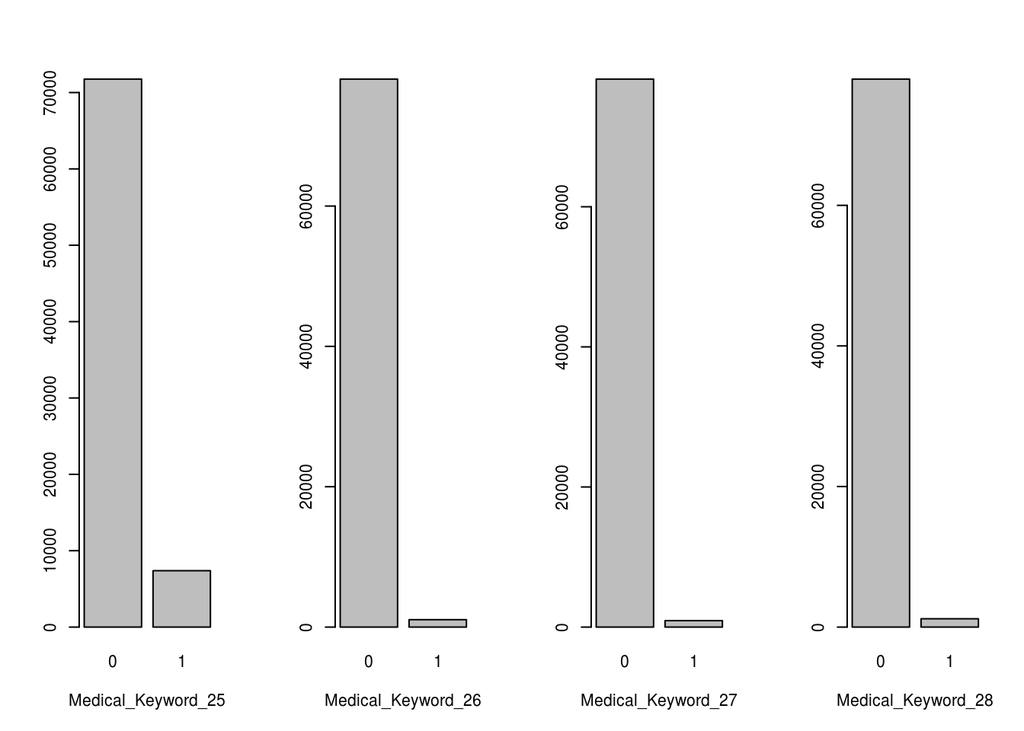

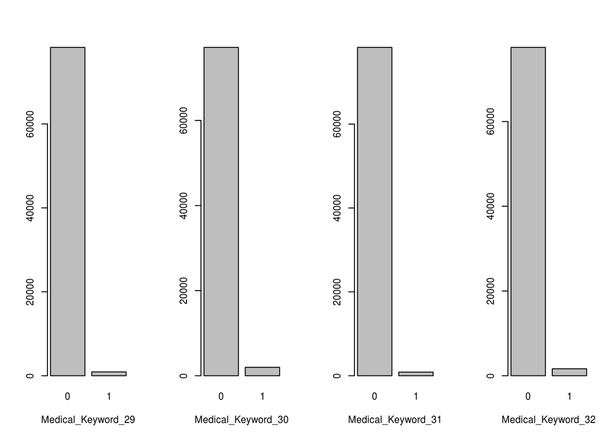

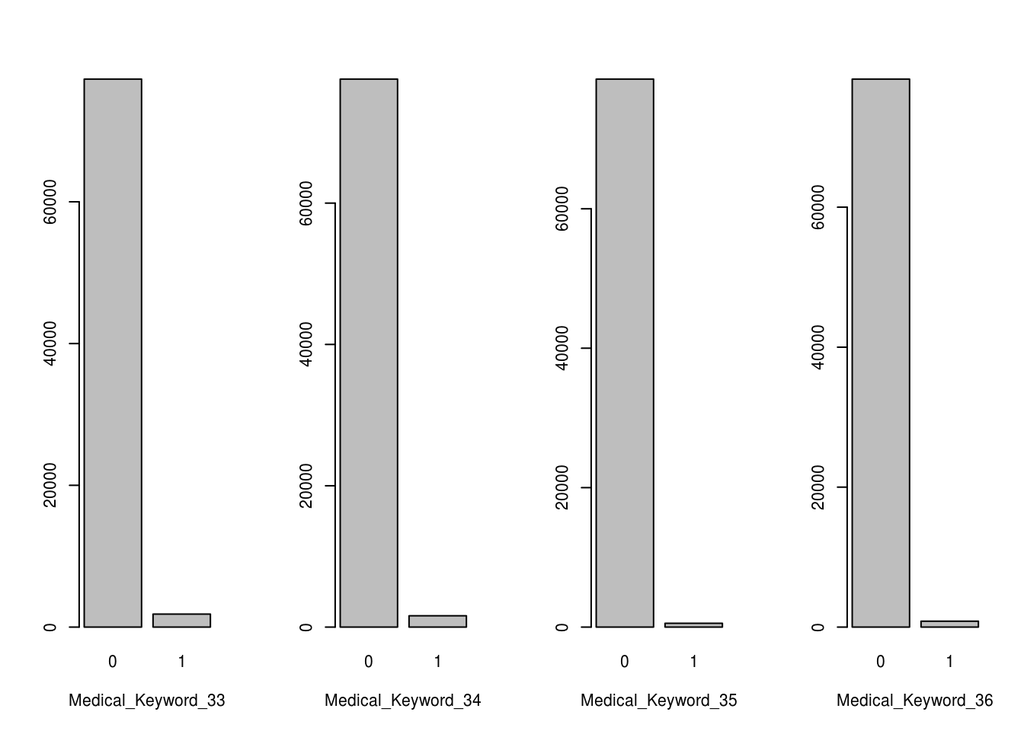

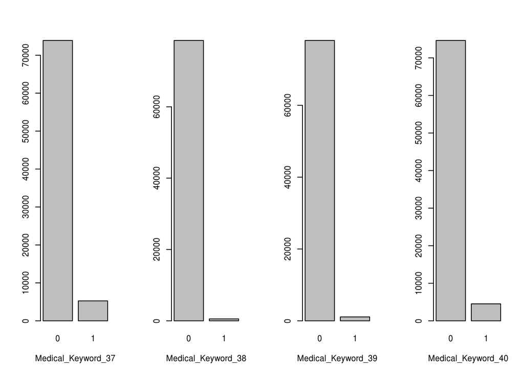

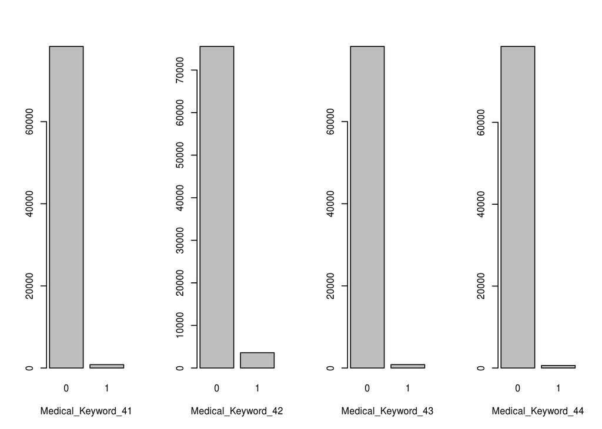

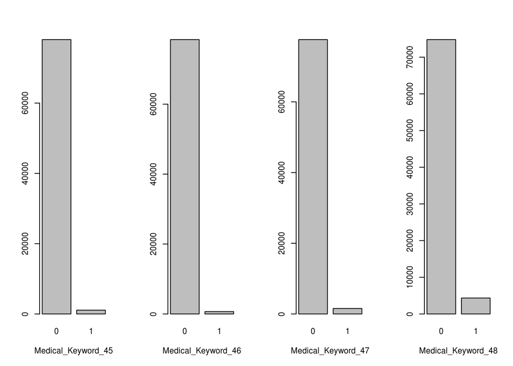

#### Response

This is the target variable, an ordinal variable relating to the final decision associated with an application.

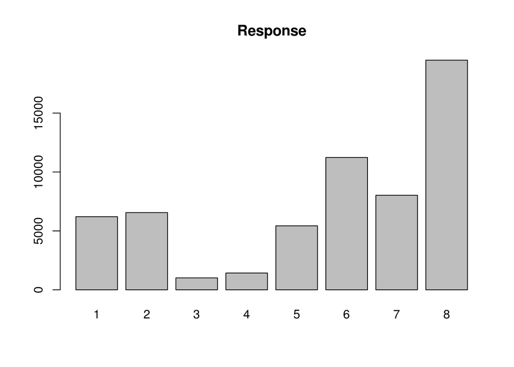

```r
par(mfcol = c(1,1))
barplot(table(train[, 'Response']), main = 'Response')
```

```r
round(table(all_data$Response)/nrow(all_data),3)
```

```
## numeric(0)
```